# 2021年4月22日 非参数作业

tassadar667

2021/4/22

# **1**

## 1.1

```r
bm.test=function(x,y,q=0.5){
  xy=c(x,y)
  mxy=quantile(xy,q)
  a=sum(x>mxy)
  m=length(x)
  n=length(y)
  t=a+sum(y>mxy)
  p1=0
  for (i in 0:a) {
    p1=p1+p(i,m,n,t)
  }
  p1=2*min(p1,1-p1)
  z1=(a-m*t/(m+n))/sqrt(m*n*t*(m+n-t)/(m+n)^3)
  p2=2*(1-pnorm(abs(z1)))
  if(a*(m+n)>m*t){
    c=-0.5
  }
  else{
    c=0.5
  }
  z2=(a+c-m*t/(m+n))/sqrt(m*n*t*(m+n-t)/(m+n)^3)
  p3=2*(1-pnorm(abs(z2)))
  ans=list("p-value"=p1,'p-value.nrom'=p2,'p-value.Cnorm'=p3)
}

p=function(k,m,n,t){
  choose(m,k)*choose(n,t-k)/choose(m+n,t)
}
x=c(698,688,675,656,655,648,640,639,620)
y=c(780,754,740,712,693,680,621)

ans=bm.test(x,y)
print(ans)
```

```
## $`p-value`
## [1] 0.04055944
##
## $`p-value.nrom`
## [1] 0.01174338
##
## $`p-value.Cnorm`
## [1] 0.04381979
```

三种的P-value均小于0.05，其中修正的正态近似较为接近准确值，未修正的差距较大，在小样本情况下误差较大。 在$\alpha=0.05$的水平下，认为两者的中位数不相同。

```r
ans=bm.test(x,y,q=0.25)
print(ans)
```

```
## $`p-value`
## [1] 0.7846154
##
## $`p-value.nrom`
## [1] 0.3827331
##
## $`p-value.Cnorm`
## [1] 0.7710841
```

在$\alpha=0.05$的水平下，认为两者的0.25分位数相同。

```r
ans=bm.test(x,y,q=0.75)
print(ans)
```

```
## $`p-value`
## [1] 0.03846154
##
## $`p-value.nrom`
## [1] 0.008828761
##
## $`p-value.Cnorm`
## [1] 0.04168008
```

在$\alpha=0.05$的水平下，认为两者的0.75分位数不相同。

## 1.2

### 1.2.1

$H_0:$B组0.25分位数小于等于A组

$H_1:$B组0.25分位数大于A组

利用BM检验进行假设检验

修改原函数为单边检验函数

```r
bm.test=function(x,y,q=0.5,two.side=TRUE){
  if(two.side==TRUE){
    index=2
  }
  else{
    index=1
  }
  xy=c(x,y)
  mxy=quantile(xy,q)
  a=sum(x>mxy)
  m=length(x)
  n=length(y)
  t=a+sum(y>mxy)
  p1=0
  for (i in 0:a) {
    p1=p1+p(i,m,n,t)
  }
  p1=index*min(p1,1-p1)
  z1=(a-m*t/(m+n))/sqrt(m*n*t*(m+n-t)/(m+n)^3)
  p2=index*(1-pnorm(abs(z1)))
  if(a*(m+n)>m*t){
    c=-0.5
  }
  else{
    c=0.5
  }
  z2=(a+c-m*t/(m+n))/sqrt(m*n*t*(m+n-t)/(m+n)^3)
  p3=index*(1-pnorm(abs(z2)))
  ans=list("p-value"=p1,'p-value.nrom'=p2,'p-value.Cnorm'=p3)
}
```

进行检验

```r
x=c(10,8,12,16,5,9,7,11,6)
y=c(12,15,20,18,13,14,9,16)
ans=bm.test(x,y,q=0.25,two.side = FALSE)
print(ans)
```

```
## $`p-value`
## [1] 0.08823529
##
## $`p-value.nrom`
## [1] 0.03185791
##
## $`p-value.Cnorm`
## [1] 0.08918939
```

在显著性水平为0.05前提下，不能否定原假设“B组0.25分位数小于等于A组”。但是在显著性水平为0.1前提下，可以否定原假设，即认为B组0.25分位数大于A组。

### 1.2.2

$H_0:$B组0.75分位数小于等于A组

$H_1:$B组0.75分位数大于A组

进行检验

```r
ans=bm.test(x,y,q=0.75,two.side = FALSE)
print(ans)
```

```
## $`p-value`
## [1] 0.2411765
##
## $`p-value.nrom`
## [1] 0.1002207
##
## $`p-value.Cnorm`
## [1] 0.2396181
```

在显著性水平为0.05前提下，不能否定原假设“B组0.75分位数小于等于A组”。

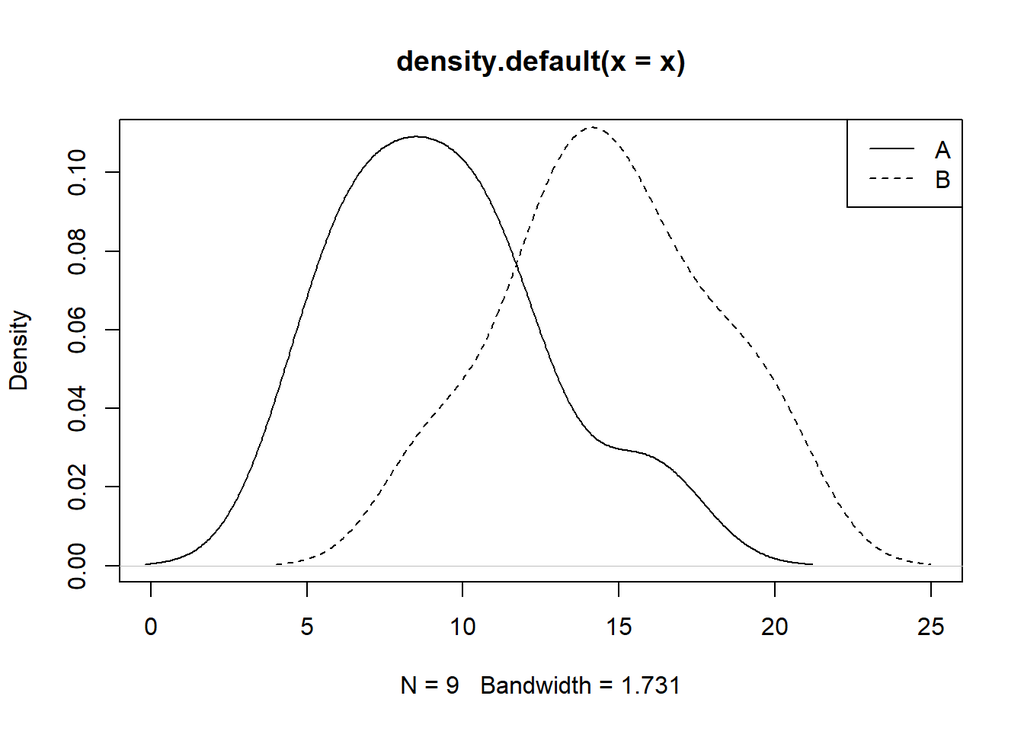

```r
plot(density(x),xlim=c(0,25))
lines(density(y),lty=2)
legend("topright",legend = c("A","B"),lty = c(1,2))
```

**但是根据图像来看，两组数据的0.25和0.75分位数均是B组大于A组，导致检验中无法否定原假设的原因在于样本量过少，可能是发生了偶然事件使得图像中B组的0.25和0.75分位数大于A组。可以通过增大样本量进一步增加准确性。**

# **2**

## 2.1

$H_0:$B组中位数小于等于A组

$H_1:$B组中位数大于A组

## 2.2

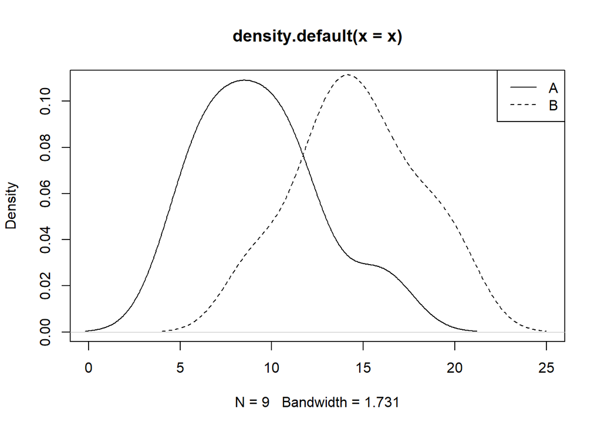

```r
plot(density(x),xlim=c(0,25))
lines(density(y),lty=2)
legend("topright",legend = c("A","B"),lty = c(1,2))
```

## 2.3

利用BM进行中位数检验

## 2.4

```r
ans=bm.test(x,y,q=0.5,two.side = FALSE)
print(ans)
```

```
## $`p-value`
## [1] 0.01336898
##
## $`p-value.nrom`
## [1] 0.003774834
##
## $`p-value.Cnorm`
## [1] 0.01470627
```

在显著性水平为0.05前提下否定原假设，即认为B组中位数大于A组，即使用毒品后攻击性更强。

## 2.5

证据充分，只有0.013的概率是偶然因素导致B组中位数大于A组。

# **3**

**One-sample Wilcoxon signed rank test**

A Wilcoxon signed-rank test is a nonparametric test that can be used to determine whether two dependent samples were selected from populations having *the same distribution*.

- 要求样本对称
- 研究的是对称分布的对称中心

**Wilcoxon rank sum test**

- 相互独立
- 要求顺序数据
- 不要求对称
- 两样本具有相似分布
- 比较的是两样本的位置参数

**Wilcoxon signed rank test on paired samples**

- 要求样本对称
- 检验的是两样本是否具有相同的中位数（对称中心）

**Wilcoxon test assumptions**

Wilcoxon signed rank要求样本对称，而Wilcoxon rank sum test不要求对称

The Mann–Whitney U test / Wilcoxon rank-sum test is not the same as the Wilcoxon signed-rank test, although both are nonparametric and involve summation of ranks. The Mann–Whitney U test is applied to **independent samples**. The Wilcoxon signed-rank test is applied to **matched or dependent samples**.

## a

检验的是中位数，故采用One-sample Wilcoxon signed rank test

$H_0:$小鼠体重均值为25g

$H_1:$小鼠体重均值不为25g

```r
library(datarium)
wilcox.test(mice$weight-25)
```

```
##
##  Wilcoxon signed rank exact test
##
## data:  mice$weight - 25
## V = 0, p-value = 0.001953
## alternative hypothesis: true location is not equal to 0
```

在显著性水平为0.05情况下，拒绝原假设，即认为小鼠的体重中位数不为25。

## b

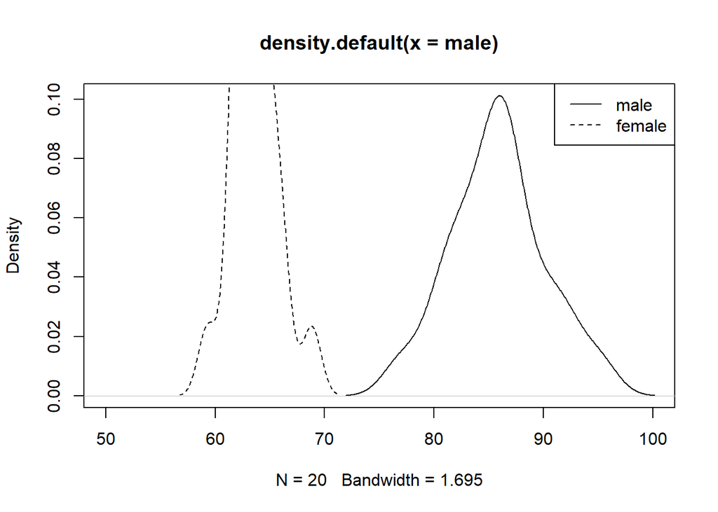

```r
male=genderweight$group=='M'
male=genderweight$weight[male]
female=genderweight$group=='F'
female=genderweight$weight[female]
plot(density(male),xlim=c(50,100))
lines(density(female),lty=2)
legend("topright",legend = c("male","female"),lty = c(1,2))
```

两者具有相似分布，比较的是均值即位置参数，采用Wilcoxon rank sum test

$H_0:$男性体重平均水平小于等于女性

$H_1:$男性体重平均水平大于女性

```r
wilcox.test(male,female,alternative = 'greater')
```

```
##
##  Wilcoxon rank sum exact test
##
## data:  male and female
## W = 400, p-value = 7.254e-12
## alternative hypothesis: true location shift is greater than 0
```

在显著性水平为0.05情况下，拒绝原假设，认为男性体重平均水平大于女性。

## c

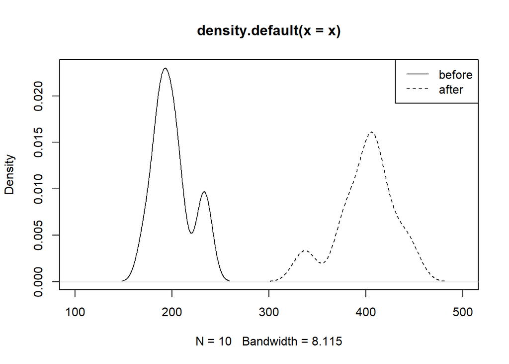

```r
x=mice2$before
y=mice2$after
plot(density(x),xlim=c(100,500))
lines(density(y),lty=2)
legend("topright",legend = c("before","after"),lty = c(1,2))
```

由于样本是配对数据，采用Wilcoxon signed rank test on paired samples

$H_0:$小鼠体重无显著上升

$H_1:$小鼠体重有显著上升

```r
wilcox.test(x,y,paired = TRUE,alternative = 'less')
```

```
##
##  Wilcoxon signed rank exact test
##
## data:  x and y
## V = 0, p-value = 0.0009766
## alternative hypothesis: true location shift is less than 0
```

在显著性水平为0.05情况下，拒绝原假设，认为小鼠体重有显著上升。